# Reef Water Column Productivity — RUN4 Respirometry Analysis

- Show All Code
- Hide All Code
- View Source

Plankton P/R rates, chamber comparison, and QC checks

Author

Jordan Vest

Published

September 18, 2026

## Overview

Summary document for respo runs measuring plankton production/respiration rates from coastal seawater samples at Kewalo. Samples were put into two chamber types and in a temperature-regulated water bath (Inkbird). Started under dark conditions, turned on light later. Continuous measurements from PreSens OXY-10.

Starting with RUN3, we began testing chamber design as an additional variable — some samples were run in 350 mL BOD bottles, others in 500 mL mason jars, to check whether chambers/optode type meaningfully affect rates.

This document walks through: the rate-calculation pipeline, a chamber-type comparison, data analysis decisions and a quick check on O2 rate v temperature correlation. Scripts from Dr. Nyssa Silbiger have been adapted for this analysis. Anthropic Claude was used for code development and troubleshooting.

```r
library(tidyverse)
library(here)
library(patchwork)
library(broom)
```

```r
acclim_sec <- 1800

RespoMeta <- read_csv(here("data","respirometry","kewalo","kewalo_respo_meta.csv"))
BioData   <- read_csv(here("data","respirometry","kewalo","measurements_kewalo.csv"))
RespoR_PR <- read_csv(here("data","respirometry","kewalo","PnR_rates.csv"))

path_run4 <- here("data","respirometry","kewalo","rawo2","K_RUN4")

# S2.3_RUN4 raw trace (used by both the exclusion writeup and the sensitivity check)
raw_s23 <- read_csv(skip = 1, file.path(path_run4, "S2.3_RUN4_O2.csv")) %>%
  dplyr::select(Date, Time, Value, Temp) %>%
  unite(Date, Time, col = "Time", sep = " ") %>%
  mutate(Time = mdy_hms(Time)) %>%
  drop_na()

# All RUN4 samples, cut to their DARK/LIGHT windows from metadata
RespoMeta_run4 <- RespoMeta %>%
  filter(run_block == "K_RUN4") %>%
  mutate(start_time = mdy_hms(paste(date, start_time)),
         stop_time  = mdy_hms(paste(date, stop_time)))

read_raw <- function(filename) {
  raw <- read_csv(skip = 1, file.path(path_run4, filename)) %>%
    dplyr::select(Date, Time, Value, Temp) %>%
    unite(Date, Time, col = "Time", sep = " ") %>%
    mutate(Time = mdy_hms(Time)) %>%
    drop_na(Time, Value, Temp) %>%
    arrange(Time)

  meta_rows <- RespoMeta_run4 %>% filter(FileID_csv == filename)

  meta_rows %>%
    pmap_dfr(function(light_dark, start_time, stop_time, ...) {
      raw %>%
        filter(Time >= start_time & Time <= stop_time) %>%
        mutate(t_sec = as.numeric(difftime(Time, first(Time), units = "secs"))) %>%
        filter(t_sec > acclim_sec) %>%
        mutate(light_dark = light_dark, sample_ID = sub("_O2.csv", "", filename))
    })
}

filenames_run4 <- list.files(path_run4, pattern = "csv$")
all_raw <- map_dfr(filenames_run4, read_raw)
light_only <- all_raw %>% filter(light_dark == "LIGHT")
```

## Data & Metadata

Sample metadata (incubation windows, site, chamber type/volume) lives in `kewalo_respo_meta.csv` and `measurements_kewalo.csv`. Every sample’s DARK/LIGHT time windows, chamber assignment, and any exclusions or truncations are tracked there.

```r
RespoMeta %>%
  filter(run_block == "K_RUN4") %>%
  left_join(BioData, by = c("sample_ID","site_ID")) %>%
  select(sample_ID, site_ID, light_dark, start_time, stop_time, chamber_type, volume_mL, notes) %>%
  knitr::kable()
```

| sample_ID | site_ID | light_dark | start_time | stop_time | chamber_type | volume_mL | notes |
| --- | --- | --- | --- | --- | --- | --- | --- |
| S1.1_RUN4 | S1 | DARK | 10:29:00 | 13:00:00 | BOD | 350 | NA |
| S1.2_RUN4 | S1 | DARK | 10:29:00 | 13:00:00 | MASON | 500 | NA |
| S1.3_RUN4 | S1 | DARK | 10:29:00 | 13:00:00 | MASON | 500 | NA |
| S1.4_RUN4 | S1 | DARK | 10:29:00 | 13:00:00 | BOD | 350 | NA |
| S2.1_RUN4 | S2 | DARK | 10:29:00 | 13:00:00 | MASON | 500 | NA |
| S2.2_RUN4 | S2 | DARK | 10:29:00 | 13:00:00 | MASON | 500 | NA |
| S2.4_RUN4 | S2 | DARK | 10:29:00 | 13:00:00 | BOD | 350 | NA |
| S1.1_RUN4 | S1 | LIGHT | 13:00:00 | 15:30:00 | BOD | 350 | NA |
| S1.2_RUN4 | S1 | LIGHT | 13:00:00 | 15:30:00 | MASON | 500 | NA |
| S1.3_RUN4 | S1 | LIGHT | 13:00:00 | 15:30:00 | MASON | 500 | NA |
| S1.4_RUN4 | S1 | LIGHT | 13:00:00 | 15:30:00 | BOD | 350 | NA |
| S2.1_RUN4 | S2 | LIGHT | 13:00:00 | 15:30:00 | MASON | 500 | NA |
| S2.2_RUN4 | S2 | LIGHT | 13:00:00 | 15:30:00 | MASON | 500 | NA |
| S2.4_RUN4 | S2 | LIGHT | 13:00:00 | 15:30:00 | BOD | 350 | NA |

## Rate Calculation Pipeline

Raw O2 data gets cut by DARK/LIGHT window times from the metadata and trimmed to drop the first 30 minutes (acclimation lag after each light transition), then thinned and fit with `LoLinR::rankLocReg()`.

The code below is the actual for-loop from `respo_seawater.R` but is not executed here.

```r
for(i in 1:length(filenames_final)) {
  FRow <- as.numeric(which(Sample_Info$FileID_csv == filenames_final[i]))

  Respo.Data1 <- read_csv(skip = 1, file.path(path.p, file.names.full[i])) %>%
    dplyr::select(Date, Time, Value, Temp) %>%
    unite(Date, Time, col = "Time", remove = TRUE, sep = " ") %>%
    drop_na() %>%
    mutate(Time = mdy_hms(Time))

  oxy_subsets <- Sample_Info[FRow,] %>%
    pmap(function(light_dark, start_time, stop_time, ...) {
      Respo.Data1 %>%
        filter(Time >= start_time & Time <= stop_time) %>%
        arrange(Time) %>%
        mutate(t_sec = as.numeric(difftime(Time, first(Time), units = "secs"))) %>%
        mutate(light_dark = light_dark) %>%
        filter(t_sec > 1800) %>%          # drop first 30 min (acclimation lag)
        filter(row_number() %% 10 == 0)   # thin to every ~20 sec
    })

  combined_oxy <- bind_rows(oxy_subsets)

  fit_reg <- function(data) {
    rankLocReg(xall = data$t_sec, yall = data$Value, alpha = 0.2, method = "pc", verbose = FALSE)
  }

  df <- combined_oxy %>%
    dplyr::select(t_sec, Value, Temp, light_dark) %>%
    nest_by(light_dark) %>% ungroup() %>%
    mutate(regs = furrr::future_map(data, fit_reg),
           Temp.C = map_dbl(map(data, "Temp"), mean),
           RegStats = map(regs, function(x) x$allRegs %>% slice(1) %>%
                             dplyr::select(Intercept = b0, umol.L.sec = b1)))

  # ... intercept/slope extracted, joined to Sample_Info, written into RespoR
}
```

Rates are then converted to per-hour units using each sample’s actual chamber volume (`volume_mL` from `measurements_kewalo.csv` — 350 mL for BOD bottles, 500 mL for mason jars), and Respiration/NetPhoto/ GrossPhoto are derived per sample.

### Rate results (RUN4)

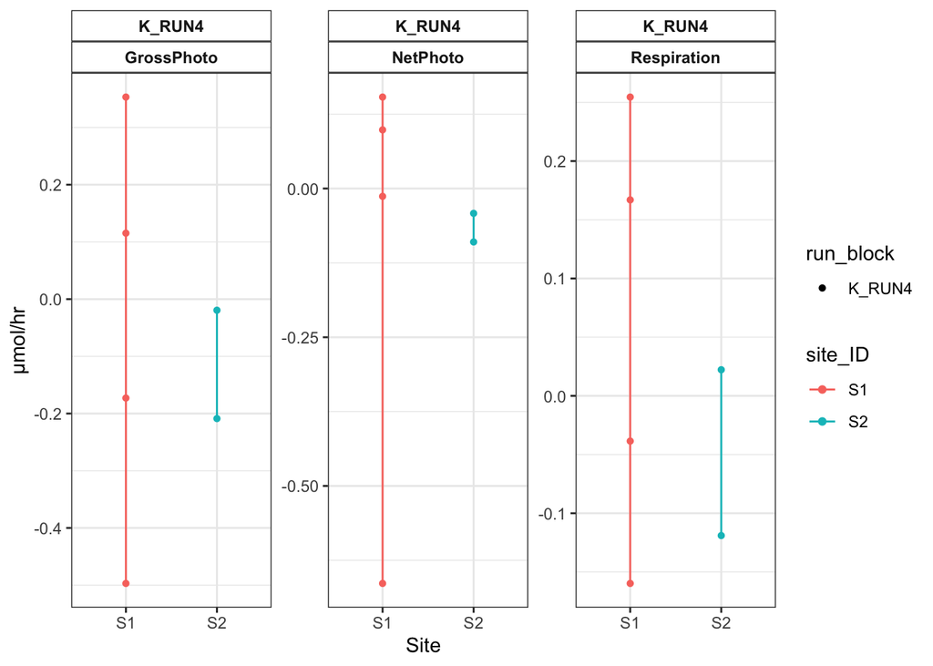

```r
RespoR_PR %>%
  filter(run_block %in% c("K_RUN3","K_RUN4")) %>%
  ggplot(aes(x = site_ID, y = Values, group = site_ID, color = site_ID, shape = run_block)) +
  geom_point() + geom_line() +
  facet_wrap(run_block ~ PR, scales = "free") +
  theme_bw() +
  labs(x = "Site", y = "µmol/hr") +
  theme(strip.background = element_rect(fill = "white"), strip.text = element_text(face = "bold"))
```

## Sample Exclusion: S2.3_RUN4

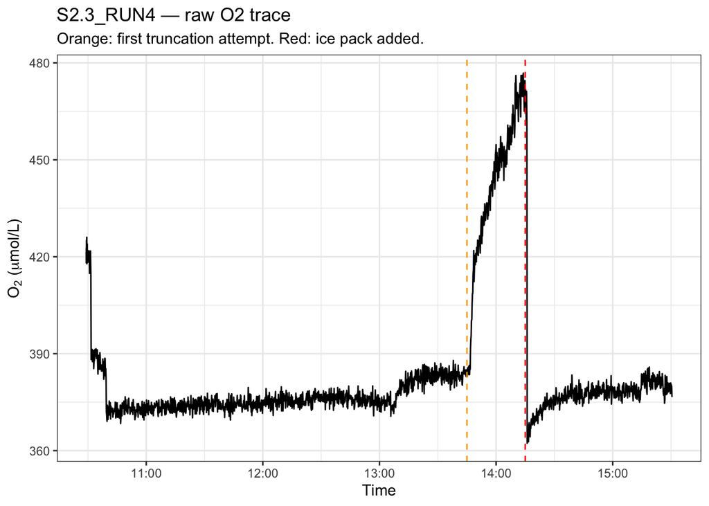

```r
ggplot(raw_s23, aes(x = Time, y = Value)) +
  geom_line() +
  geom_vline(xintercept = as.numeric(as.POSIXct("2026-09-01 13:45:00", tz = "UTC")),
             color = "orange", linetype = "dashed") +
  geom_vline(xintercept = as.numeric(as.POSIXct("2026-09-01 14:15:00", tz = "UTC")),
             color = "red", linetype = "dashed") +
  theme_bw() +
  labs(title = "S2.3_RUN4 — raw O2 trace", subtitle = "Orange: first truncation attempt. Red: ice pack added.",
       y = expression(paste("O"[2], " (", mu, "mol/L)")))
```

**How I dealt with this:**

1. Attempted to truncate the LIGHT window’s `stop_time` to 13:45:00 — left only ~15 minutes of usable data after the standard 30-minute acclimation cutoff, too few points to trust a fit.
2. **Excluded S2.3_RUN4 from the primary rate calculations** (both DARK and LIGHT) — with only 15:30 as a hard stop, any post-disturbance segment plus a consistent recovery buffer leaves too little data.

## Chamber Type Comparison

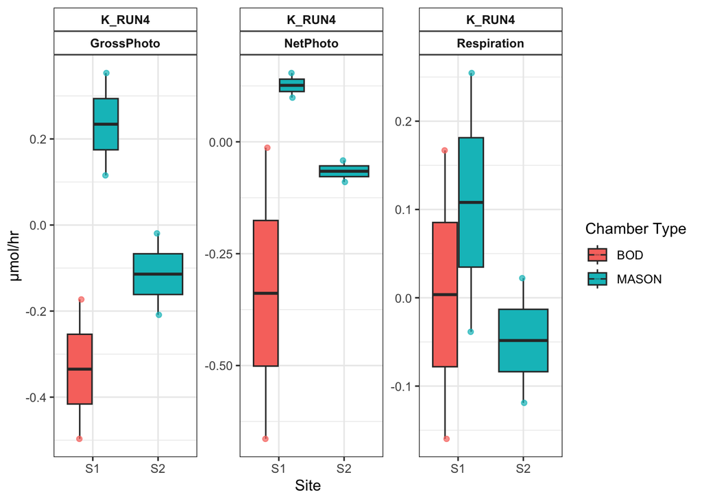

```r
RespoR_PR %>%
  filter(run_block %in% c("K_RUN3","K_RUN4")) %>%
  ggplot(aes(x = site_ID, y = Values, fill = chamber_type)) +
  geom_boxplot(outlier.shape = NA, position = position_dodge(width = 0.8)) +
  geom_point(aes(color = chamber_type),
             position = position_jitterdodge(jitter.width = 0.1, dodge.width = 0.8), alpha = 0.7) +
  facet_wrap(run_block ~ PR, scales = "free") +
  theme_bw() +
  labs(x = "Site", y = "µmol/hr", fill = "Chamber Type", color = "Chamber Type") +
  theme(strip.background = element_rect(fill = "white"), strip.text = element_text(face = "bold"))
```

### Site × Chamber Type breakdown

```r
RespoR_PR %>%
  filter(run_block == "K_RUN4") %>%
  group_by(site_ID, chamber_type, PR) %>%
  summarise(n = n(), mean_val = mean(Values, na.rm = TRUE),
            sd_val = sd(Values, na.rm = TRUE), .groups = "drop") %>%
  arrange(PR, site_ID, chamber_type) %>%
  knitr::kable(digits = 3)
```

| site_ID | chamber_type | PR | n | mean_val | sd_val |
| --- | --- | --- | --- | --- | --- |
| S1 | BOD | GrossPhoto | 2 | -0.335 | 0.229 |
| S1 | MASON | GrossPhoto | 2 | 0.234 | 0.168 |
| S2 | MASON | GrossPhoto | 2 | -0.114 | 0.134 |
| S1 | BOD | NetPhoto | 2 | -0.339 | 0.460 |
| S1 | MASON | NetPhoto | 2 | 0.126 | 0.039 |
| S2 | MASON | NetPhoto | 2 | -0.066 | 0.034 |
| S1 | BOD | Respiration | 2 | 0.004 | 0.231 |
| S1 | MASON | Respiration | 2 | 0.108 | 0.207 |
| S2 | MASON | Respiration | 2 | -0.048 | 0.100 |

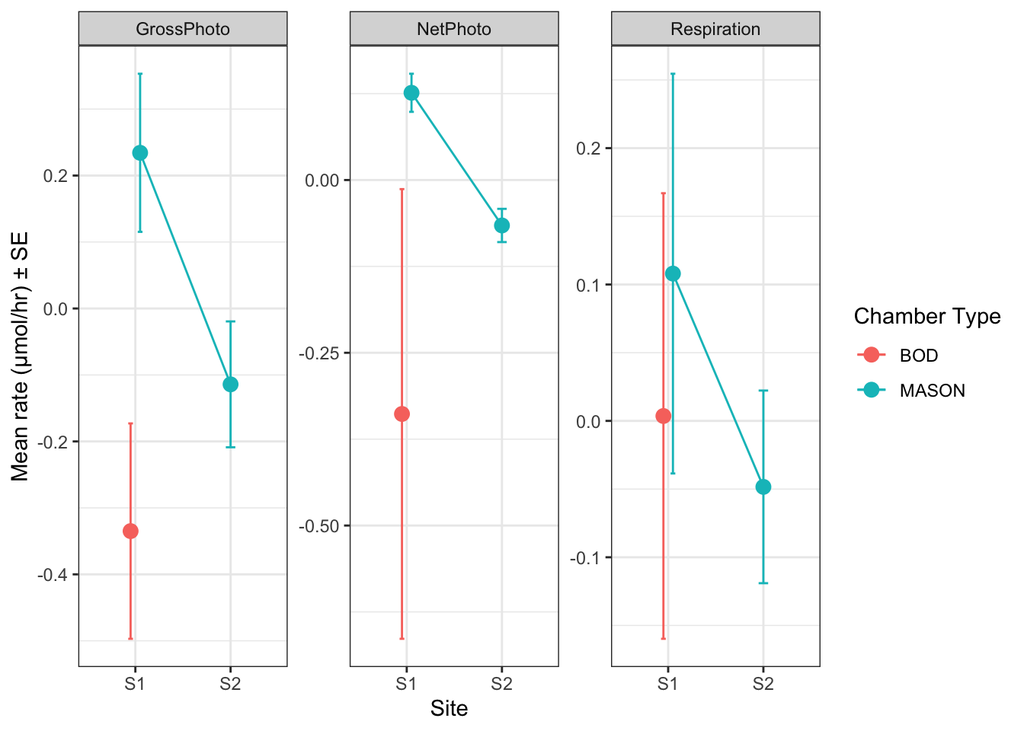

```r
RespoR_PR %>%
  filter(run_block == "K_RUN4") %>%
  group_by(site_ID, chamber_type, PR) %>%
  summarise(mean_val = mean(Values, na.rm = TRUE),
            se_val = sd(Values, na.rm = TRUE)/sqrt(n()), .groups = "drop") %>%
  ggplot(aes(x = site_ID, y = mean_val, color = chamber_type, group = chamber_type)) +
  geom_point(size = 3, position = position_dodge(width = 0.2)) +
  geom_line(position = position_dodge(width = 0.2)) +
  geom_errorbar(aes(ymin = mean_val - se_val, ymax = mean_val + se_val),
                width = 0.1, position = position_dodge(width = 0.2)) +
  facet_wrap(~PR, scales = "free_y") +
  theme_bw() +
  labs(x = "Site", y = "Mean rate (µmol/hr) ± SE", color = "Chamber Type")
```

*Note: worth confirming whether a channel-9/S2.5 BOD sample exists in your raw files that isn’t yet in this metadata — if so, Site 2’s BOD sample size is understated here.*

## Temperature vs. O2 Diagnostic

Under LIGHT conditions, the water bath temperature shifted by about 1°C (vs. minimal drift in DARK) — partly driven by the added heat from the incubation light, and partly by an ice pack added around 14:15 to cool it down. This section checks whether the O2 increases reflect real productivity or are being driven by a temperature shift.

### How I checked this

**Pass 1: full trace (DARK + LIGHT together), standardized.**

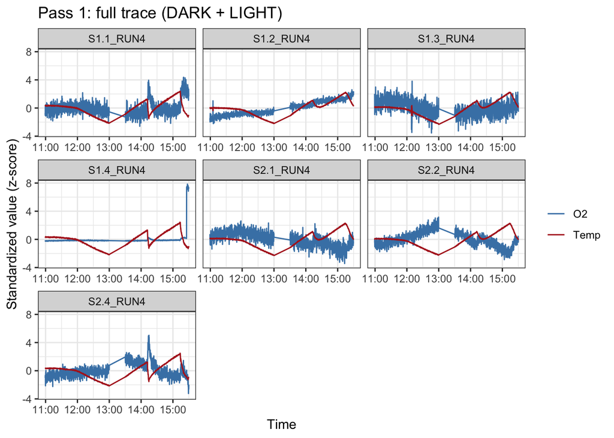

```r
all_raw %>%
  group_by(sample_ID) %>%
  mutate(O2_z = as.numeric(scale(Value)), Temp_z = as.numeric(scale(Temp))) %>%
  ungroup() %>%
  pivot_longer(cols = c(O2_z, Temp_z), names_to = "variable", values_to = "z_value") %>%
  ggplot(aes(x = Time, y = z_value, color = variable)) +
  geom_line() +
  facet_wrap(~sample_ID, scales = "free_x") +
  theme_bw() +
  labs(y = "Standardized value (z-score)", x = "Time", title = "Pass 1: full trace (DARK + LIGHT)") +
  scale_color_manual(values = c("O2_z" = "steelblue", "Temp_z" = "firebrick"),
                      labels = c("O2_z" = "O2", "Temp_z" = "Temp"), name = NULL)
```

**Pass 2: LIGHT period only, standardized.**

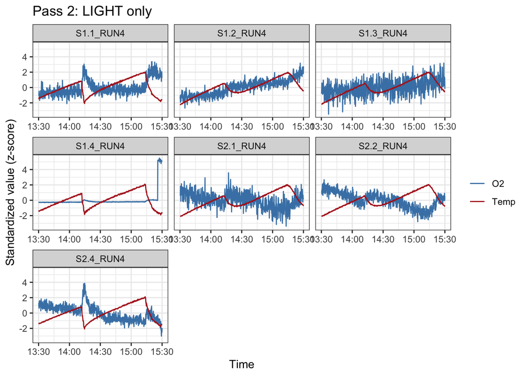

```r
light_only %>%
  group_by(sample_ID) %>%
  mutate(O2_z = as.numeric(scale(Value)), Temp_z = as.numeric(scale(Temp))) %>%
  ungroup() %>%
  pivot_longer(cols = c(O2_z, Temp_z), names_to = "variable", values_to = "z_value") %>%
  ggplot(aes(x = Time, y = z_value, color = variable)) +
  geom_line() +
  facet_wrap(~sample_ID, scales = "free_x") +
  theme_bw() +
  labs(y = "Standardized value (z-score)", x = "Time", title = "Pass 2: LIGHT only") +
  scale_color_manual(values = c("O2_z" = "steelblue", "Temp_z" = "firebrick"),
                      labels = c("O2_z" = "O2", "Temp_z" = "Temp"), name = NULL)
```

**Pass 3: literal values, dual-axis, every sample.**

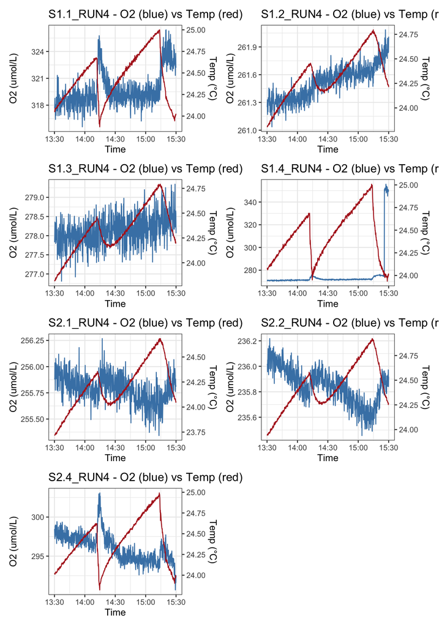

```r
plot_temp_o2_dual <- function(sample_id, data = light_only) {
  d <- data %>% filter(sample_ID == sample_id)
  if (nrow(d) == 0) return(NULL)
  o2_range <- range(d$Value); temp_range <- range(d$Temp)
  scale_factor <- diff(o2_range) / diff(temp_range)
  temp_offset <- o2_range[1] - temp_range[1] * scale_factor
  ggplot(d, aes(x = Time)) +
    geom_line(aes(y = Value), color = "steelblue") +
    geom_line(aes(y = Temp * scale_factor + temp_offset), color = "firebrick") +
    scale_y_continuous(name = "O2 (umol/L)",
                        sec.axis = sec_axis(~ (. - temp_offset) / scale_factor, name = "Temp (°C)")) +
    theme_bw() + labs(title = paste(sample_id, "- O2 (blue) vs Temp (red)"), x = "Time")
}

all_dual_plots <- map(unique(light_only$sample_ID), plot_temp_o2_dual)
wrap_plots(all_dual_plots, ncol = 2)
```

### Correlation summary (LIGHT period)

```r
light_only %>%
  group_by(sample_ID) %>%
  summarise(cor_temp_o2 = cor(Temp, Value, use = "complete.obs")) %>%
  arrange(desc(abs(cor_temp_o2))) %>%
  knitr::kable(digits = 2)
```

| sample_ID | cor_temp_o2 |
| --- | --- |
| S2.2_RUN4 | -0.87 |
| S2.1_RUN4 | -0.63 |
| S1.2_RUN4 | 0.59 |
| S2.4_RUN4 | -0.52 |
| S1.1_RUN4 | -0.37 |
| S1.4_RUN4 | -0.35 |
| S1.3_RUN4 | 0.25 |